# PD & PK/PD Integration Study Notes (with Plots & Equations)

### **1. Introduction to Pharmacodynamics (PD)**

Pharmacodynamics (PD) is the study of *what the drug does to the body*. It aims to quantify the relationship between drug **exposure** (concentration) and the physiological **response** (effect), known as an Exposure-Response (E-R) relationship.

### **2. The Emax Model**

This is the fundamental model of PD, describing how an effect increases with concentration until it reaches a maximum. It is visualized as a **dose-response curve**.

#### **Key Parameters:**

- **$E_{max}$**: The **maximum effect** a drug can produce (Efficacy).
- **$EC_{50}$**: The concentration that produces 50% of the maximum effect (Potency).
- **n**: The **Hill Coefficient**, which describes the steepness of the curve.

#### **Mathematical Forms**

**1. The Simple Emax Model:** This describes a hyperbolic relationship.
$$Effect =
\frac{E_{max} \cdot C}{EC_{50} + C}$$

**2. The Sigmoidal Emax Model (Hill Equation):** This adds the Hill coefficient `n` to describe the steepness of the classic “S”-shaped curve.
$$Effect =
\frac{E_{max} \cdot C^n}{EC_{50}^n + C^n}$$

**3. The Full Model with Baseline:** This is the most common form, adding a baseline effect ($E_0$) that exists without the drug.
$$Effect(t) = E_0 + \frac{E_{max} \cdot
C(t)^n}{EC_{50}^n + C(t)^n}$$

#### **Example Plot: Dose-Response Curve**

This plot shows the sigmoidal shape of the Emax model, labeling the key parameters.

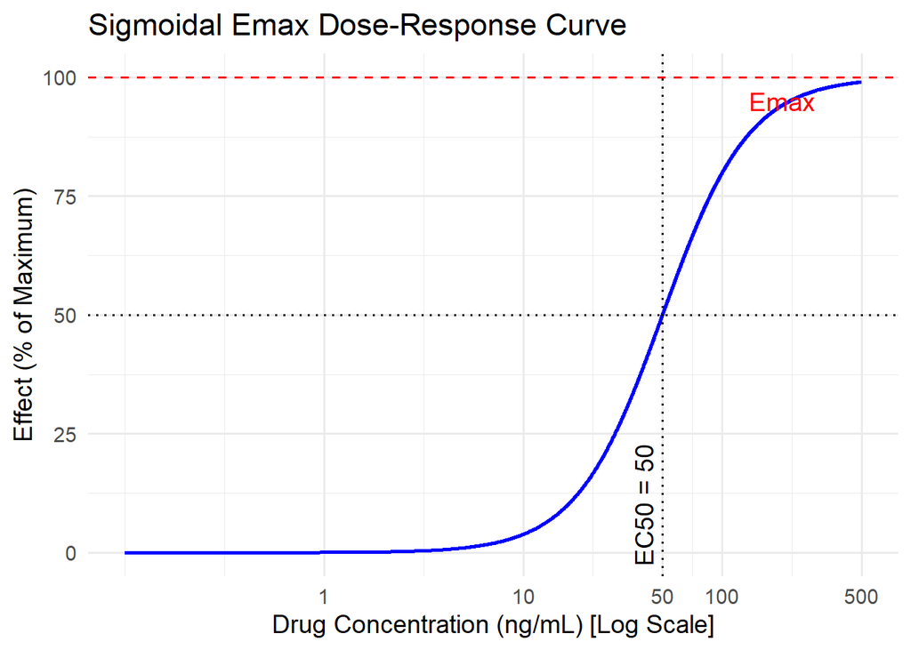

### **3. Integrating PK and PD**

A **PK/PD model** links a PK model with a PD model to describe and predict the **time course of the drug’s effect**.

### **4. Handling Time Delays: Hysteresis & the Effect Compartment**

**Hysteresis** is the phenomenon where the drug’s effect lags behind the concentration in the plasma. This is solved with the **Effect-Compartment Model**.

#### **Diagram: Effect Compartment Model**

[interactive chart not shown]

#### **Mathematical Form:**

1. **The delay equation:** Describes the change in concentration in the effect compartment ($C_e$).
   $$\frac{dC_e}{dt} = k_{e0} \cdot (C_p(t) - C_e(t))$$
2. **The linked Emax model:** The effect is now driven by $C_e$.
   $$Effect(t) = E_0 + \frac{E_{max} \cdot C_e(t)^n}{EC_{50}^n + C_e(t)^n}$$

#### **Example Plot: Hysteresis Loop & Time Course**

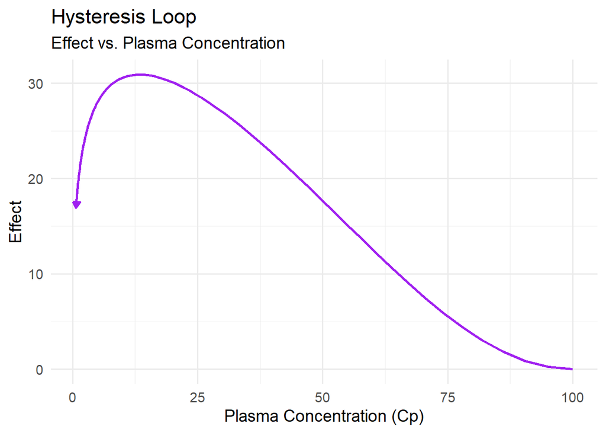

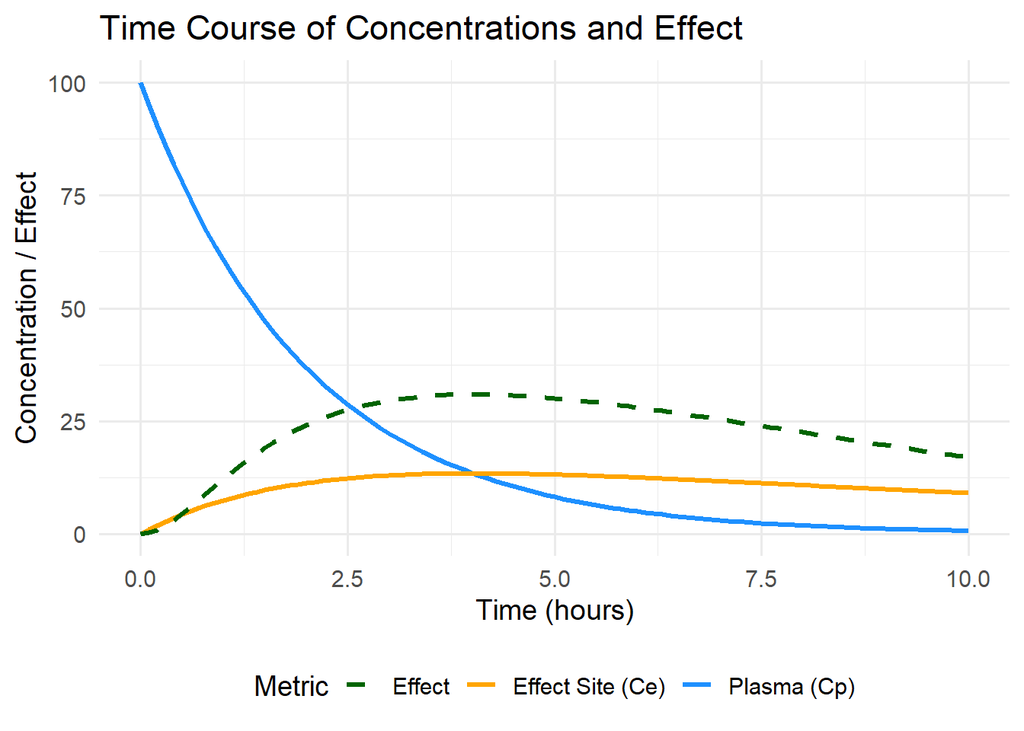

### **5. The Sequential PK/PD Modeling Workflow**

1. **Assemble and Explore Data (EDA)**
2. **Build the Population PK Model**
3. **Evaluate PK Model & Generate Exposure Metrics (EBEs)**
4. **Build the PD Model**